# GAMS in R Course

Author

Rick Dean

Abstract

The following are notes to [GAMS in R Course](https://github.com/noamross/gams-in-r-course) by Noam Ross, Chapter 1 Introduction to Generalized Additive Models.

Load the Required R Packages.

```r
library(MASS)
library(gamair)
library(mgcv)
library(data.table)
library(ggplot2)
library(magrittr)
library(RgamPkg)
library(RregressPkg)
library(RplotterPkg)
```

# 1 - Introduction to Generalized Additive Models

## 1.1 Introduction

## 1.2 Motocycle crash data: linear approach

Fit a linear model to MASS::mcycle data.

The data are measurements of acceleration of a crash-test dummy head during a motorcycle crash.

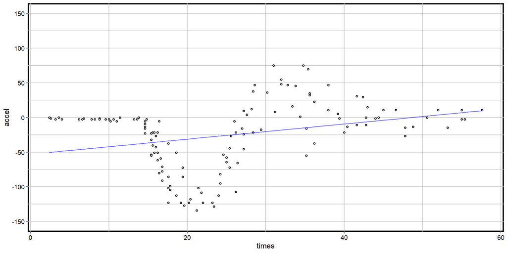

Linear fit of *times*(milliseconds) vs *accel*(g) during a motocycle crash

```r
data("mcycle")

mcycle_lm <- stats::lm(formula = accel ~ times, data = mcycle)

linear_df <- data.table::as.data.table(mcycle) %>%
  .[, fit := mcycle_lm$fitted.values] %>%
  .[, residual := mcycle_lm$residuals]

RplotterPkg::create_scatter_plot(
  df = linear_df,
  aes_x = "times",
  aes_y = "accel",
  x_title = "times",
  y_title = "accel",
  rot_y_tic_label = T,
  y_limits = c(-150, 150),
  y_major_breaks = seq(-150, 150, 50)
) + ggplot2::geom_line(aes(y = fit), color="blue", alpha=0.6)
```

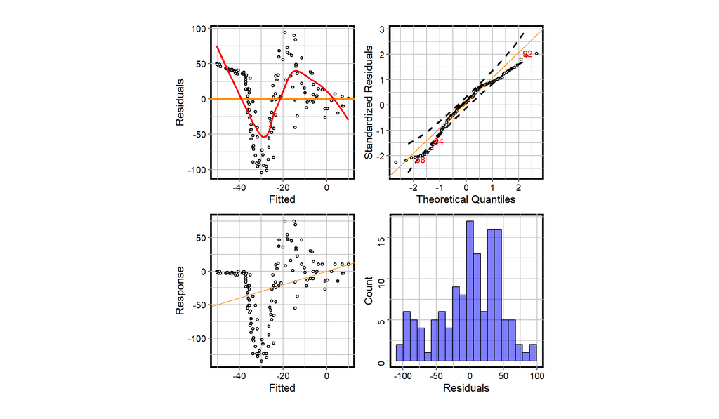

Check of motorcycle linear model

```r
RregressPkg::plot_model_check(
  fitted_v = mcycle_lm$fitted.values,
  response_v = mcycle$accel,
  residual_v = mcycle_lm$residuals,
  histo_fill = "blue",
  histo_alpha = 0.5,
  ref_line_color = "darkorange"
)
```

## 1.3 Motocycle crash data: non-linear approach

Fit a model to the `mcycle` data where `accel` has a smooth, nonlinear relation to `times` using `mgcv::gam()` function.

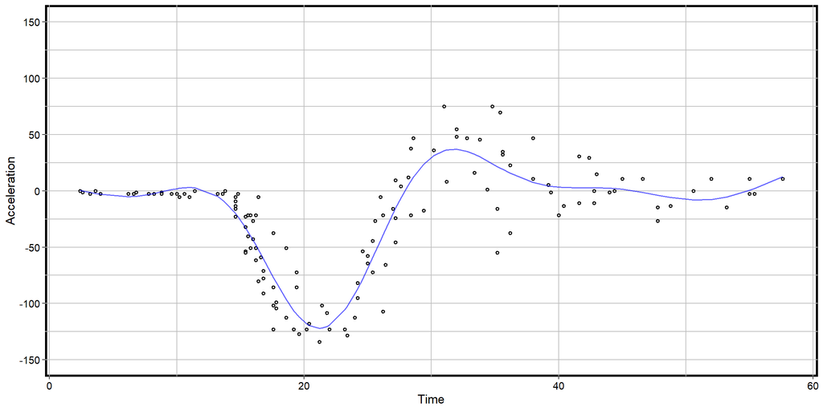

Non-linear fit of *times*(milliseconds) vs *accel*(g) during a motocycle crash

```r
mcycle_mod_gam <- mgcv::gam(formula = accel ~ s(times), data = mcycle)

nonlinear_df <- data.frame(
  times = mcycle_mod_gam$model$times,
  accel = mcycle_mod_gam$model$accel,
  fit = mcycle_mod_gam$fitted.values,
  residual = mcycle_mod_gam$residuals
)
RplotterPkg::create_scatter_plot(
  df = nonlinear_df,
  aes_x = "times",
  aes_y = "accel",
  connect = F,
  show_pts = T,
  x_title = "Time",
  y_title = "Acceleration",
  y_limits = c(-150, 150),
  y_major_breaks = seq(-150, 150, 50),
  rot_y_tic_label = T
) + ggplot2::geom_line(aes(y = fit), color="blue", alpha=0.6)
```

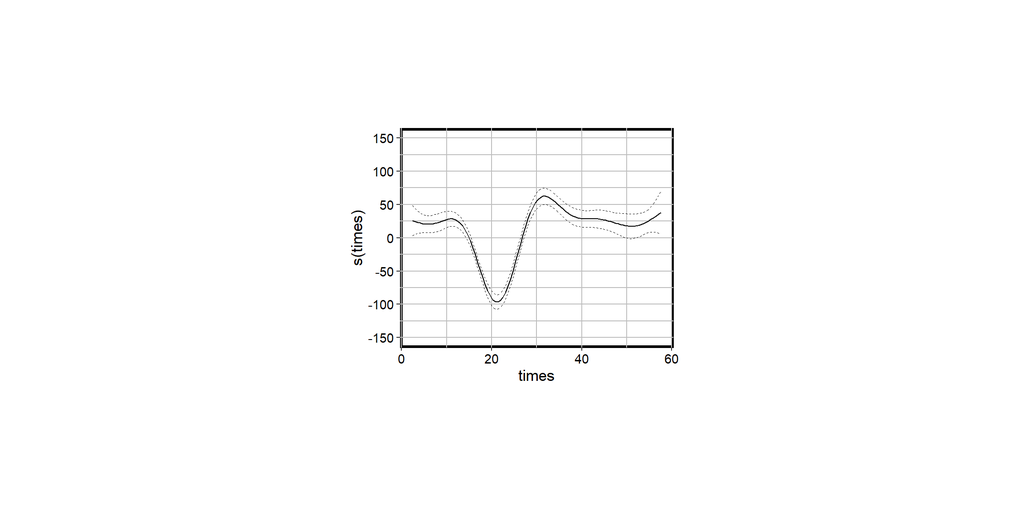

GAM model term *times* in nonlinear fit of acceleration *s(times)* during a motocycle crash

```r
RgamPkg::plot_gam_1d(
  gam_model = mcycle_mod_gam,
  columns = 1,
  col_width = 10,
  row_height = 8,
  se_fill = "white",
  line_width = 0.5,
  y_limits = c(-150, 150),
  y_major_breaks = seq(-150, 150, 50)
)
```

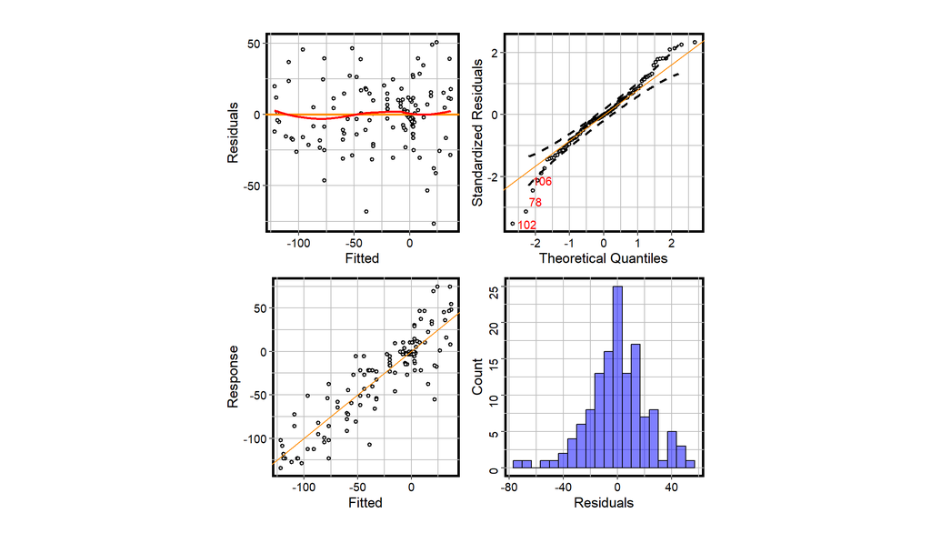

Check of motorcycle non-linear model

```r
RregressPkg::plot_model_check(
  fitted_v = mcycle_mod_gam$fitted.values,
  response_v = mcycle$accel,
  residual_v = mcycle_mod_gam$residuals,
  histo_fill = "blue",
  histo_alpha = 0.5,
  ref_line_color = "darkorange"
)
```

## 1.4 Parts of non-linear function

Plot the basis functions that make up the GAM model.

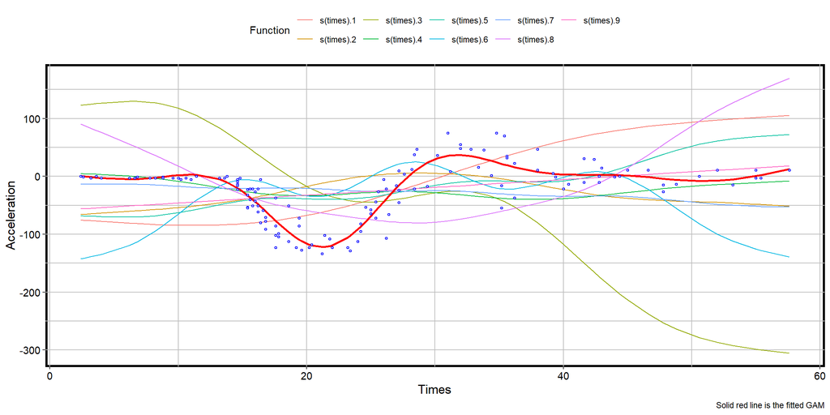

Basis functions that make up the GAM MASS::mcycle model

```r
RgamPkg::plot_basis_splines_1d(
  gam_model = mcycle_mod_gam,
  term = "times",
  show_points = T,
  pts_color = "blue",
  legend_pos = "top",
  x_title = "Times",
  y_title = "Acceleration",
  caption = "Solid red line is the fitted GAM",
  rot_y_tic_label = T
)
```

## 1.6 Setting complexity of the motorcycle model

Fit a GAM with 3 basis functions and plot.

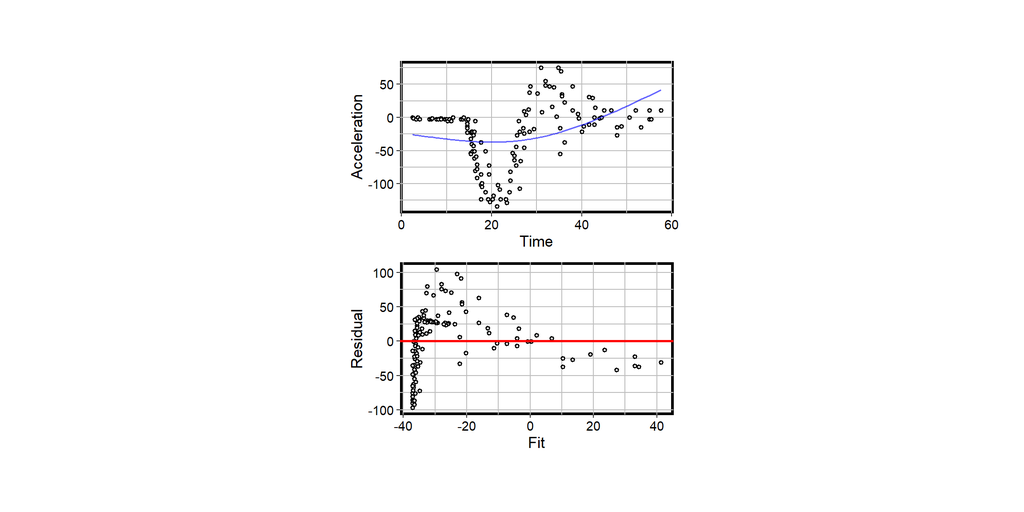

Nonlinear fit and residual of motorcycle data using 3 basis functions

```r
mcycle_gam_3 <- mgcv::gam(formula = accel ~ s(times, k = 3), data = mcycle)

nonlinear_3_df <- data.frame(
  times = mcycle_gam_3$model$times,
  accel = mcycle_gam_3$model$accel,
  fit = mcycle_gam_3$fitted.values,
  residual = mcycle_gam_3$residuals
)
nonlinear_3_plot <- RplotterPkg::create_scatter_plot(
  df = nonlinear_3_df,
  aes_x = "times",
  aes_y = "accel",
  connect = F,
  show_pts = T,
  x_title = "Time",
  y_title = "Acceleration",
 # y_limits = c(-150, 150),
 # y_major_breaks = seq(-150, 150, 50),
  rot_y_tic_label = T
) + ggplot2::geom_line(aes(y = fit), color="blue", alpha=0.6)

nonlinear_3_residual_plot <- RplotterPkg::create_scatter_plot(
  df = nonlinear_3_df,
  aes_x = "fit",
  aes_y = "residual",
  x_title = "Fit",
  y_title = "Residual",
  rot_y_tic_label = T,
 # y_limits = c(-150, 150),
 # y_major_breaks = seq(-150, 150, 50)
) + geom_hline(yintercept = 0, color = "red", linewidth = 1)

layout <- list(
  plots = list(nonlinear_3_plot, nonlinear_3_residual_plot),
  rows = c(1,2),
  cols = c(1,1)
)
RplotterPkg::multi_panel_grid(
  layout = layout,
  col_widths = 10,
  row_heights = c(6,6)
)
```

Fit a GAM with 20 basis functions and plot.

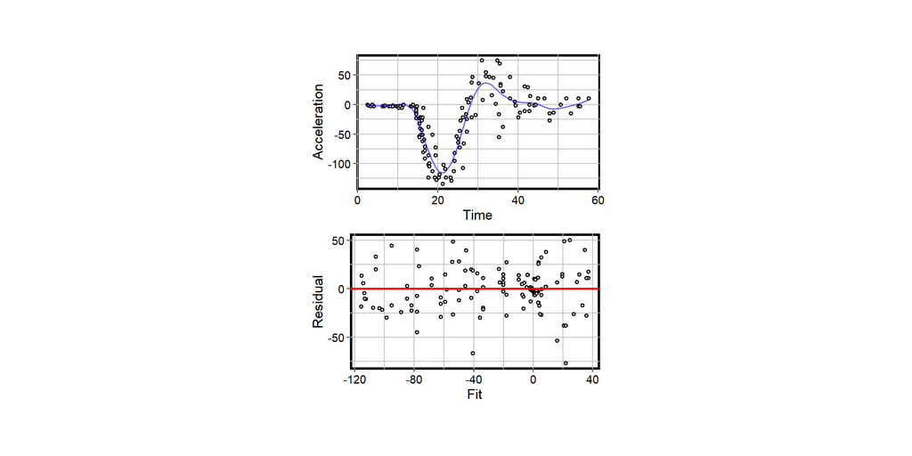

Nonlinear fit and residual of motorcycle data using 20 basis functions

```r
mcycle_gam_20 <- mgcv::gam(formula = accel ~ s(times, k = 20), data = mcycle)

nonlinear_20_df <- data.frame(
  times = mcycle_gam_20$model$times,
  accel = mcycle_gam_20$model$accel,
  fit = mcycle_gam_20$fitted.values,
  residual = mcycle_gam_20$residuals
)
nonlinear_20_plot <- RplotterPkg::create_scatter_plot(
  df = nonlinear_20_df,
  aes_x = "times",
  aes_y = "accel",
  connect = F,
  show_pts = T,
  x_title = "Time",
  y_title = "Acceleration",
#  y_limits = c(-150, 150),
#  y_major_breaks = seq(-150, 150, 50),
  rot_y_tic_label = T
) + ggplot2::geom_line(aes(y = fit), color="blue", alpha=0.6)

nonlinear_20_residual_plot <- RplotterPkg::create_scatter_plot(
  df = nonlinear_20_df,
  aes_x = "fit",
  aes_y = "residual",
  x_title = "Fit",
  y_title = "Residual",
  rot_y_tic_label = T,
#  y_limits = c(-150, 150),
#  y_major_breaks = seq(-150, 150, 50)
) + geom_hline(yintercept = 0, color = "red", linewidth = 1)

layout <- list(
  plots = list(nonlinear_20_plot, nonlinear_20_residual_plot),
  rows = c(1,2),
  cols = c(1,1)
)
RplotterPkg::multi_panel_grid(
  layout = layout,
  col_widths = 10,
  row_heights = c(6,6)
)
```

## 1.7 Using smoothing parameters to avoid overfitting

> The smoothing parameter balances between likelihood and wiggliness to optimize model fit.

Plot the nonlinear fit GAM model with smoothing parameters 0.1 and 0.0001.

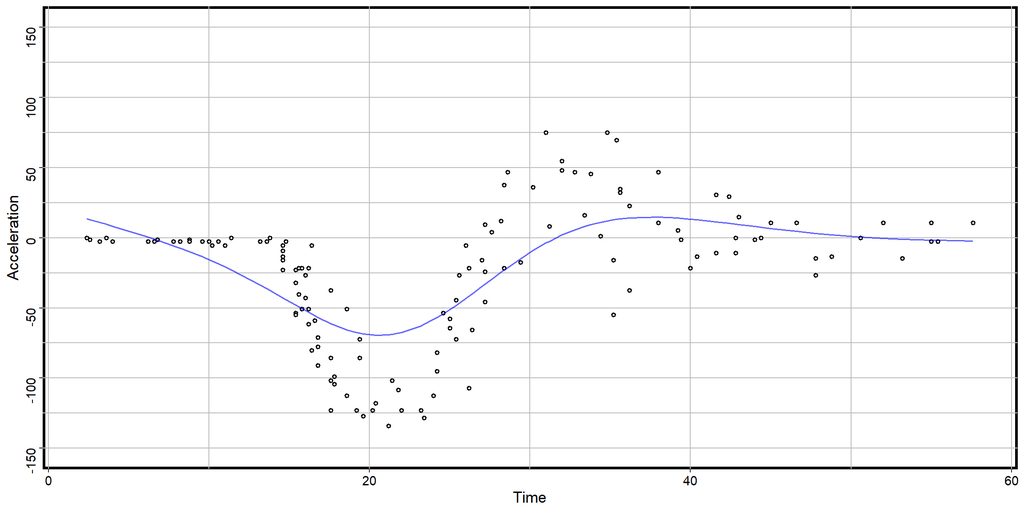

Nonlinear fit GAM model with smoothing parameters 0.1

```r
smooth_gam_1 <- mgcv::gam(formula = accel ~ s(times), data = mcycle, sp = 0.1)
smooth_gam_1_df <- data.frame(
  times = smooth_gam_1$model$times,
  accel = smooth_gam_1$model$accel,
  fit = smooth_gam_1$fitted.values
)
RplotterPkg::create_scatter_plot(
  df = smooth_gam_1_df,
  aes_x = "times",
  aes_y = "accel",
  connect = F,
  show_pts = T,
  x_title = "Time",
  y_title = "Acceleration",
  y_limits = c(-150, 150),
  y_major_breaks = seq(-150, 150, 50)
) + ggplot2::geom_line(aes(y = fit), color="blue", alpha=0.6)
```

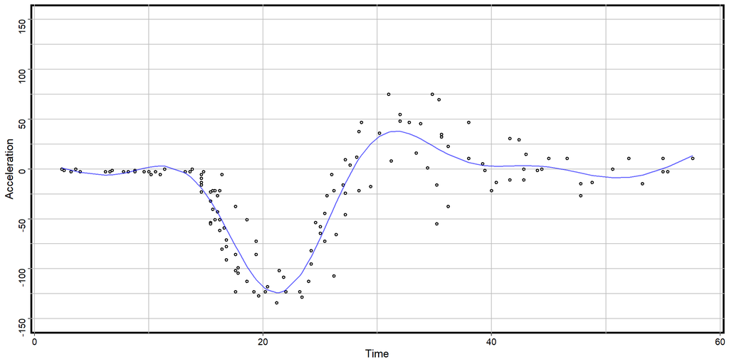

Nonlinear fit GAM model with smoothing parameters 0.0001

```r
smooth_gam_0001 <- mgcv::gam(formula = accel ~ s(times), data = mcycle, sp = 0.0001)
smooth_gam_0001_df <- data.frame(
  times = smooth_gam_0001$model$times,
  accel = smooth_gam_0001$model$accel,
  fit = smooth_gam_0001$fitted.values
)
RplotterPkg::create_scatter_plot(
  df = smooth_gam_0001_df,
  aes_x = "times",
  aes_y = "accel",
  connect = F,
  show_pts = T,
  x_title = "Time",
  y_title = "Acceleration",
  y_limits = c(-150, 150),
  y_major_breaks = seq(-150, 150, 50)
) + ggplot2::geom_line(aes(y = fit), color="blue", alpha=0.6)
```

## 1.10 Multivariate GAMs of auto performance

> Multivariate GAMs can contain a mixture of smooths, linear effects, and continuous and categorical variables.

Fit a GAM model to city.mpg with weight, length, and price from the `gamair::mpg` package.

Show the relationships among the response and independent terms.

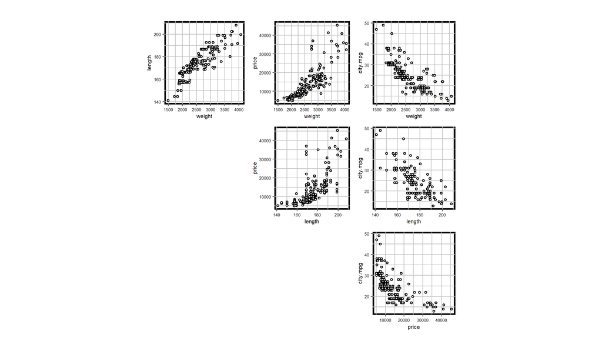

Relationships among *city.mpg*, *weight*, *length*, *price*

```r
data("mpg", package = "gamair")
var_name_scaling_lst <- list(
  weight = NULL,
  length = NULL,
  price = NULL,
  city.mpg = NULL
)
RregressPkg::plot_pairs(
  df = mpg,
  var_name_scaling = var_name_scaling_lst,
  rot_y_tic_label = T,
  plot_dim = 16
)
```

Plot the GAM model’s terms and their relationship with the response city.mpg.

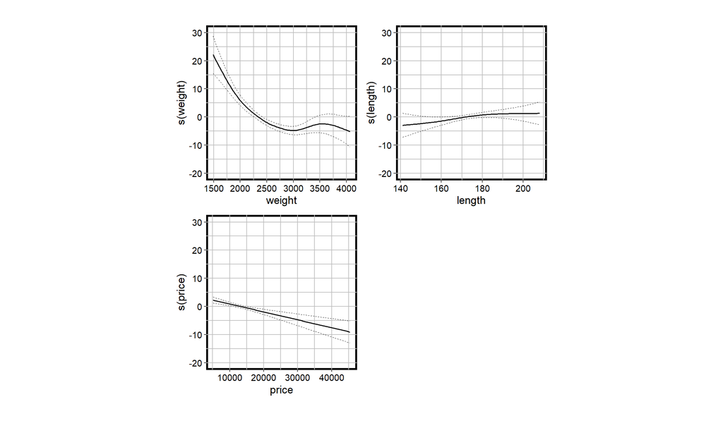

GAM model terms related to *city.mpg* response

```r
city_mpg_gam <- mgcv::gam(formula = city.mpg ~ s(weight) + s(length) + s(price), data = mpg, method = "REML")

RgamPkg::plot_gam_1d(
  gam_model = city_mpg_gam,
  col_width = 8,
  row_height = 8,
  se_fill = "white",
  y_limits = c(-20, 30),
  y_major_breaks = seq(-20, 30, 10),
  line_width = 0.7
)
```

Check the GAM model for its fit to city.mpg.

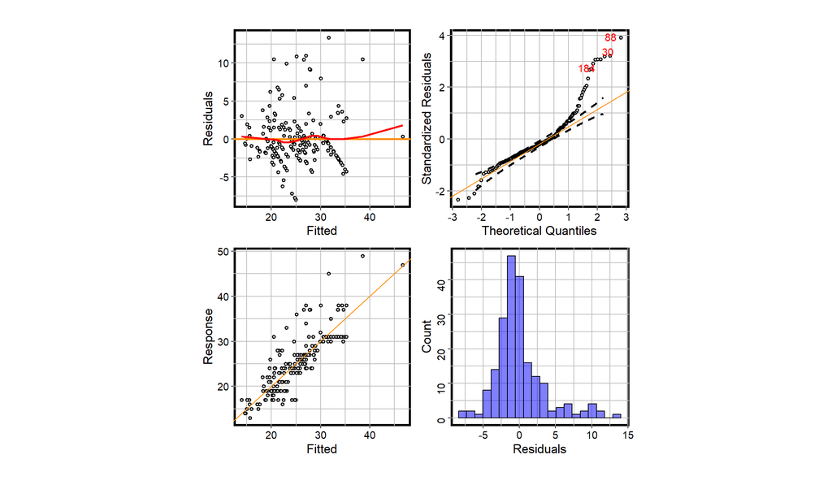

Check of GAM model for its fit to *city.mpg*.

```r
RregressPkg::plot_model_check(
  fitted_v = city_mpg_gam$fitted.values,
  response_v = city_mpg_gam$model$city.mpg,
  residual_v = city_mpg_gam$residuals,
  histo_fill = "blue",
  histo_alpha = 0.5,
  ref_line_color = "darkorange"
)
```

## 1.11 Adding categorial to the auto performance model

Add categorical terms fuel, drive, and style to the above GAM model for city.mpg.

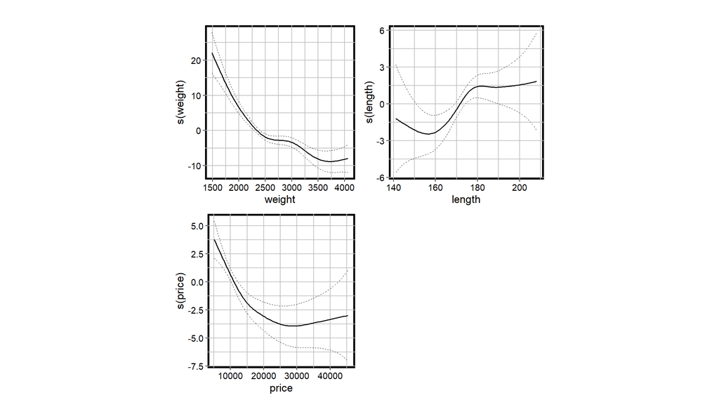

GAM model with categorical terms related to *city.mpg* response

```r
data("mpg", package = "gamair")
city_mpg_2_gam <- mgcv::gam(formula = city.mpg ~ s(weight) + s(length) + s(price) + fuel + drive + style, data = mpg, method = "REML")

RgamPkg::plot_gam_1d(
  gam_model = city_mpg_2_gam,
  col_width = 8,
  row_height = 8,
  se_fill = "white",
  line_width = 0.7
)
```

## 1.12 Category-level smooths for different auto types

Make each of the smooth terms weight, length, and price depend on the drive category variable using by= in the smooth terms.

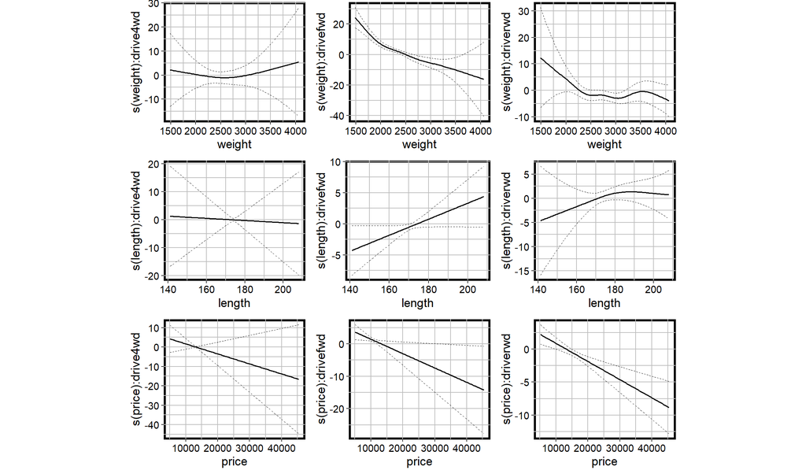

GAM model with categorical term using the *by* parameter.

```r
data("mpg", package = "gamair")
city_mpg_3_gam <- mgcv::gam(formula = city.mpg ~ s(weight, by = drive) + s(length, by = drive) + s(price, by = drive), data = mpg, method = "REML")

RgamPkg::plot_gam_1d(
  gam_model = city_mpg_3_gam,
  columns = 3,
  col_width = 7.0,
  row_height = 6.0,
  se_fill = "white",
  line_width = 0.7
)
```